# 101220_Rubangisa

Wayne Rubangisa

2025-05-16

# LIFE EXPECTANCY ANALYSIS

## Download and load data to R Studio

### Country Population

```r
country_population <- read.csv("country_population.csv")
head(country_population)
```

```
##   Country.Name Country.Code    Indicator.Name Indicator.Code    X1960    X1961
## 1        Aruba          ABW Population, total    SP.POP.TOTL    54211    55438
## 2  Afghanistan          AFG Population, total    SP.POP.TOTL  8996351  9166764
## 3       Angola          AGO Population, total    SP.POP.TOTL  5643182  5753024
## 4      Albania          ALB Population, total    SP.POP.TOTL  1608800  1659800
## 5      Andorra          AND Population, total    SP.POP.TOTL    13411    14375
## 6   Arab World          ARB Population, total    SP.POP.TOTL 92490932 95044497
##      X1962     X1963     X1964     X1965     X1966     X1967     X1968
## 1    56225     56695     57032     57360     57715     58055     58386
## 2  9345868   9533954   9731361   9938414  10152331  10372630  10604346
## 3  5866061   5980417   6093321   6203299   6309770   6414995   6523791
## 4  1711319   1762621   1814135   1864791   1914573   1965598   2022272
## 5    15370     16412     17469     18549     19647     20758     21890
## 6 97682294 100411076 103239902 106174988 109230593 112406932 115680165
##       X1969     X1970     X1971     X1972     X1973     X1974     X1975
```

[output cut: 48 more lines]

### Fertility Rate

```r
fertility_rate <- read.csv("fertility_rate.csv")
head(fertility_rate)
```

```
##   Country.Name Country.Code                           Indicator.Name
## 1        Aruba          ABW Fertility rate, total (births per woman)
## 2  Afghanistan          AFG Fertility rate, total (births per woman)
## 3       Angola          AGO Fertility rate, total (births per woman)
## 4      Albania          ALB Fertility rate, total (births per woman)
## 5      Andorra          AND Fertility rate, total (births per woman)
## 6   Arab World          ARB Fertility rate, total (births per woman)
##   Indicator.Code    X1960   X1961   X1962    X1963    X1964    X1965    X1966
## 1 SP.DYN.TFRT.IN 4.820000 4.65500 4.47100 4.271000 4.059000 3.842000 3.625000
## 2 SP.DYN.TFRT.IN 7.450000 7.45000 7.45000 7.450000 7.450000 7.450000 7.450000
## 3 SP.DYN.TFRT.IN 7.478000 7.52400 7.56300 7.592000 7.611000 7.619000 7.618000
## 4 SP.DYN.TFRT.IN 6.489000 6.40100 6.28200 6.133000 5.960000 5.773000 5.581000
## 5 SP.DYN.TFRT.IN       NA      NA      NA       NA       NA       NA       NA
## 6 SP.DYN.TFRT.IN 6.948747 6.97137 6.99235 7.009265 7.020105 7.023159 7.015824
##      X1967    X1968    X1969    X1970    X1971    X1972    X1973    X1974
```

[output cut: 48 more lines]

### Life Expectancy

```r
life_expectancy <- read.csv("life_expectancy.csv")
head(life_expectancy)
```

```
##   Country.Name Country.Code                          Indicator.Name
## 1        Aruba          ABW Life expectancy at birth, total (years)
## 2  Afghanistan          AFG Life expectancy at birth, total (years)
## 3       Angola          AGO Life expectancy at birth, total (years)
## 4      Albania          ALB Life expectancy at birth, total (years)
## 5      Andorra          AND Life expectancy at birth, total (years)
## 6   Arab World          ARB Life expectancy at birth, total (years)
##   Indicator.Code    X1960   X1961    X1962    X1963    X1964    X1965  X1966
## 1 SP.DYN.LE00.IN 65.66200 66.0740 66.44400 66.78700 67.11300 67.43500 67.762
## 2 SP.DYN.LE00.IN 32.29200 32.7420 33.18500 33.62400 34.06000 34.49500 34.928
## 3 SP.DYN.LE00.IN 33.25100 33.5730 33.91400 34.27200 34.64500 35.03100 35.426
## 4 SP.DYN.LE00.IN 62.27900 63.2980 64.18700 64.91100 65.46100 65.84800 66.108
## 5 SP.DYN.LE00.IN       NA      NA       NA       NA       NA       NA     NA
## 6 SP.DYN.LE00.IN 46.82506 47.4077 47.98888 48.57223 49.15917 49.74434 50.319
##      X1967    X1968    X1969    X1970    X1971    X1972    X1973    X1974
```

[output cut: 48 more lines]

### Life Expectancy Data

```r
life_expectancy_data <- read.csv("Life Expectancy Data.csv")
head(life_expectancy_data)
```

```
##       Country Year     Status Life.expectancy Adult.Mortality infant.deaths
## 1 Afghanistan 2015 Developing            65.0             263            62
## 2 Afghanistan 2014 Developing            59.9             271            64
## 3 Afghanistan 2013 Developing            59.9             268            66
## 4 Afghanistan 2012 Developing            59.5             272            69
## 5 Afghanistan 2011 Developing            59.2             275            71
## 6 Afghanistan 2010 Developing            58.8             279            74
##   Alcohol percentage.expenditure Hepatitis.B Measles  BMI under.five.deaths
## 1    0.01              71.279624          65    1154 19.1                83
## 2    0.01              73.523582          62     492 18.6                86
## 3    0.01              73.219243          64     430 18.1                89
## 4    0.01              78.184215          67    2787 17.6                93
## 5    0.01               7.097109          68    3013 17.2                97
## 6    0.01              79.679367          66    1989 16.7               102
##   Polio Total.expenditure Diphtheria HIV.AIDS       GDP Population
```

[output cut: 20 more lines]

## Exploratory Data Analysis

### Display Variable Names

See the names of all variables in the data set `Life Expectancy Data`

```r
names(life_expectancy_data)
```

```
##  [1] "Country"                         "Year"
##  [3] "Status"                          "Life.expectancy"
##  [5] "Adult.Mortality"                 "infant.deaths"
##  [7] "Alcohol"                         "percentage.expenditure"
##  [9] "Hepatitis.B"                     "Measles"
## [11] "BMI"                             "under.five.deaths"
## [13] "Polio"                           "Total.expenditure"
## [15] "Diphtheria"                      "HIV.AIDS"
## [17] "GDP"                             "Population"
## [19] "thinness..1.19.years"            "thinness.5.9.years"
## [21] "Income.composition.of.resources" "Schooling"
```

```r
cat(names(life_expectancy_data), sep = "\n")
```

```
## Country
## Year
## Status
## Life.expectancy
## Adult.Mortality
## infant.deaths
## Alcohol
## percentage.expenditure
## Hepatitis.B
## Measles
## BMI
## under.five.deaths
## Polio
## Total.expenditure
## Diphtheria
## HIV.AIDS
## GDP
## Population
## thinness..1.19.years
## thinness.5.9.years
## Income.composition.of.resources
## Schooling
```

### Display the first 5 rows

Preview the first 5 observations in the data set.

```r
head(life_expectancy_data, 5)
```

```
##       Country Year     Status Life.expectancy Adult.Mortality infant.deaths
## 1 Afghanistan 2015 Developing            65.0             263            62
## 2 Afghanistan 2014 Developing            59.9             271            64
## 3 Afghanistan 2013 Developing            59.9             268            66
## 4 Afghanistan 2012 Developing            59.5             272            69
## 5 Afghanistan 2011 Developing            59.2             275            71
##   Alcohol percentage.expenditure Hepatitis.B Measles  BMI under.five.deaths
## 1    0.01              71.279624          65    1154 19.1                83
## 2    0.01              73.523582          62     492 18.6                86
## 3    0.01              73.219243          64     430 18.1                89
## 4    0.01              78.184215          67    2787 17.6                93
## 5    0.01               7.097109          68    3013 17.2                97
##   Polio Total.expenditure Diphtheria HIV.AIDS       GDP Population
## 1     6              8.16         65      0.1 584.25921   33736494
## 2    58              8.18         62      0.1 612.69651     327582
## 3    62              8.13         64      0.1 631.74498   31731688
## 4    67              8.52         67      0.1 669.95900    3696958
## 5    68              7.87         68      0.1  63.53723    2978599
##   thinness..1.19.years thinness.5.9.years Income.composition.of.resources
## 1                 17.2               17.3                           0.479
## 2                 17.5               17.5                           0.476
## 3                 17.7               17.7                           0.470
## 4                 17.9               18.0                           0.463
## 5                 18.2               18.2                           0.454
##   Schooling
## 1      10.1
## 2      10.0
## 3       9.9
## 4       9.8
## 5       9.5
```

### Display the bottom 10 rows

View the last 10 observations of the data set.

```r
tail(life_expectancy_data, 10)
```

```
##       Country Year     Status Life.expectancy Adult.Mortality infant.deaths
## 2929 Zimbabwe 2009 Developing            50.0             587            30
## 2930 Zimbabwe 2008 Developing            48.2             632            30
## 2931 Zimbabwe 2007 Developing            46.6              67            29
## 2932 Zimbabwe 2006 Developing            45.4               7            28
## 2933 Zimbabwe 2005 Developing            44.6             717            28
## 2934 Zimbabwe 2004 Developing            44.3             723            27
## 2935 Zimbabwe 2003 Developing            44.5             715            26
## 2936 Zimbabwe 2002 Developing            44.8              73            25
## 2937 Zimbabwe 2001 Developing            45.3             686            25
## 2938 Zimbabwe 2000 Developing            46.0             665            24
##      Alcohol percentage.expenditure Hepatitis.B Measles  BMI under.five.deaths
## 2929    4.64               1.040021          73     853 29.0                45
## 2930    3.56              20.843429          75       0 28.6                46
## 2931    3.88              29.814566          72     242 28.2                46
```

[output cut: 40 more lines]

### Display the data types

Shows what type of data each column holds.

```r
sapply(life_expectancy_data, class)
```

```
##                         Country                            Year
##                     "character"                       "integer"
##                          Status                 Life.expectancy
##                     "character"                       "numeric"
##                 Adult.Mortality                   infant.deaths
##                       "integer"                       "integer"
##                         Alcohol          percentage.expenditure
##                       "numeric"                       "numeric"
##                     Hepatitis.B                         Measles
##                       "integer"                       "integer"
##                             BMI               under.five.deaths
##                       "numeric"                       "integer"
##                           Polio               Total.expenditure
##                       "integer"                       "numeric"
##                      Diphtheria                        HIV.AIDS
##                       "integer"                       "numeric"
##                             GDP                      Population
##                       "numeric"                       "numeric"
##            thinness..1.19.years              thinness.5.9.years
##                       "numeric"                       "numeric"
## Income.composition.of.resources                       Schooling
##                       "numeric"                       "numeric"
```

We need a cleaner way to present this though.

```r
result <- sapply(life_expectancy_data, class)
result
```

```
##                         Country                            Year
##                     "character"                       "integer"
##                          Status                 Life.expectancy
##                     "character"                       "numeric"
##                 Adult.Mortality                   infant.deaths
##                       "integer"                       "integer"
##                         Alcohol          percentage.expenditure
##                       "numeric"                       "numeric"
##                     Hepatitis.B                         Measles
##                       "integer"                       "integer"
##                             BMI               under.five.deaths
##                       "numeric"                       "integer"
##                           Polio               Total.expenditure
##                       "integer"                       "numeric"
##                      Diphtheria                        HIV.AIDS
##                       "integer"                       "numeric"
##                             GDP                      Population
##                       "numeric"                       "numeric"
##            thinness..1.19.years              thinness.5.9.years
##                       "numeric"                       "numeric"
## Income.composition.of.resources                       Schooling
##                       "numeric"                       "numeric"
```

```r
result <- sapply(life_expectancy_data, class)
data.frame(Column = names(result), Class = result)
```

```
##                                                          Column     Class
## Country                                                 Country character
## Year                                                       Year   integer
## Status                                                   Status character
## Life.expectancy                                 Life.expectancy   numeric
## Adult.Mortality                                 Adult.Mortality   integer
## infant.deaths                                     infant.deaths   integer
## Alcohol                                                 Alcohol   numeric
## percentage.expenditure                   percentage.expenditure   numeric
## Hepatitis.B                                         Hepatitis.B   integer
## Measles                                                 Measles   integer
## BMI                                                         BMI   numeric
## under.five.deaths                             under.five.deaths   integer
## Polio                                                     Polio   integer
## Total.expenditure                             Total.expenditure   numeric
## Diphtheria                                           Diphtheria   integer
## HIV.AIDS                                               HIV.AIDS   numeric
## GDP                                                         GDP   numeric
## Population                                           Population   numeric
## thinness..1.19.years                       thinness..1.19.years   numeric
## thinness.5.9.years                           thinness.5.9.years   numeric
## Income.composition.of.resources Income.composition.of.resources   numeric
## Schooling                                             Schooling   numeric
```

Let’s see if we can remove the extra (the first column).

```r
result <- cat(sapply(life_expectancy_data, class), sep = "\n")
```

```
## character
## integer
## character
## numeric
## integer
## integer
## numeric
## numeric
## integer
## integer
## numeric
## integer
## integer
## numeric
## integer
## numeric
## numeric
## numeric
## numeric
## numeric
## numeric
## numeric
```

```r
result
```

[output not shown]

```r
names(result)
```

[output not shown]

We still need the names though. So we need to find a way to get the names and values.

```r
result
```

[output not shown]

```r
result[]
```

[output not shown]

```r
class(result)
```

```
## [1] "NULL"
```

```r
unname(result)
```

[output not shown]

```r
data.frame(Column = names(result), Class = unname(result))
```

```
## data frame with 0 columns and 0 rows
```

```r
sapply(life_expectancy_data, class)
```

```
##                         Country                            Year
##                     "character"                       "integer"
##                          Status                 Life.expectancy
##                     "character"                       "numeric"
##                 Adult.Mortality                   infant.deaths
##                       "integer"                       "integer"
##                         Alcohol          percentage.expenditure
##                       "numeric"                       "numeric"
##                     Hepatitis.B                         Measles
##                       "integer"                       "integer"
##                             BMI               under.five.deaths
##                       "numeric"                       "integer"
##                           Polio               Total.expenditure
##                       "integer"                       "numeric"
##                      Diphtheria                        HIV.AIDS
##                       "integer"                       "numeric"
##                             GDP                      Population
##                       "numeric"                       "numeric"
##            thinness..1.19.years              thinness.5.9.years
##                       "numeric"                       "numeric"
## Income.composition.of.resources                       Schooling
##                       "numeric"                       "numeric"
```

It checks out. We can move to the next tasks.

### Shape of the dataset.

```r
dim(life_expectancy_data)
```

```
## [1] 2938   22
```

```r
cat("Rows:", dim(life_expectancy_data)[1], "\n")
```

```
## Rows: 2938
```

```r
cat("Columns:", dim(life_expectancy_data)[2])
```

```
## Columns: 22
```

Another way:

```r
rows <- nrow(life_expectancy_data)
cols <- ncol(life_expectancy_data)
cat("Rows:", rows, "\n")
```

```
## Rows: 2938
```

```r
cat("Columns:", cols)
```

```
## Columns: 22
```

### Drop Duplicate Rows

First of all, let’s see how many duplicated observations we have in our dataset.

`duplicated(life_expectancy_data)` returns a logical vector. Instead of printing the vector, we want to know how many trues we have in said vector.

```r
sum(duplicated(life_expectancy_data))
```

```
## [1] 0
```

Well, it looks like we don’t need to drop duplicates, since there aren’t any. In which case, we move on to the next task.

### Number of missing values in each column

```r
colSums(is.na(life_expectancy_data))
```

```
##                         Country                            Year
##                               0                               0
##                          Status                 Life.expectancy
##                               0                              10
##                 Adult.Mortality                   infant.deaths
##                              10                               0
##                         Alcohol          percentage.expenditure
##                             194                               0
##                     Hepatitis.B                         Measles
##                             553                               0
##                             BMI               under.five.deaths
##                              34                               0
##                           Polio               Total.expenditure
##                              19                             226
##                      Diphtheria                        HIV.AIDS
##                              19                               0
##                             GDP                      Population
##                             448                             652
##            thinness..1.19.years              thinness.5.9.years
##                              34                              34
## Income.composition.of.resources                       Schooling
##                             167                             163
```

Now, let’s make our output presentable.

```r
data.frame(Columns = names(colSums(is.na(life_expectancy_data))), class = unname(colSums(is.na(life_expectancy_data))))
```

```
##                            Columns class
## 1                          Country     0
## 2                             Year     0
## 3                           Status     0
## 4                  Life.expectancy    10
## 5                  Adult.Mortality    10
## 6                    infant.deaths     0
## 7                          Alcohol   194
## 8           percentage.expenditure     0
## 9                      Hepatitis.B   553
## 10                         Measles     0
## 11                             BMI    34
## 12               under.five.deaths     0
## 13                           Polio    19
## 14               Total.expenditure   226
## 15                      Diphtheria    19
## 16                        HIV.AIDS     0
## 17                             GDP   448
## 18                      Population   652
## 19            thinness..1.19.years    34
## 20              thinness.5.9.years    34
## 21 Income.composition.of.resources   167
## 22                       Schooling   163
```

```r
library(dplyr)
data.frame(Columns = names(colSums(is.na(life_expectancy_data))), class = unname(colSums(is.na(life_expectancy_data)))) %>%
  arrange(desc(class))
```

```
##                            Columns class
## 1                       Population   652
## 2                      Hepatitis.B   553
## 3                              GDP   448
## 4                Total.expenditure   226
## 5                          Alcohol   194
## 6  Income.composition.of.resources   167
## 7                        Schooling   163
## 8                              BMI    34
## 9             thinness..1.19.years    34
## 10              thinness.5.9.years    34
## 11                           Polio    19
## 12                      Diphtheria    19
## 13                 Life.expectancy    10
## 14                 Adult.Mortality    10
## 15                         Country     0
## 16                            Year     0
## 17                          Status     0
## 18                   infant.deaths     0
## 19          percentage.expenditure     0
## 20                         Measles     0
## 21               under.five.deaths     0
## 22                        HIV.AIDS     0
```

### Use boxplots to check for outliers in quantitative variables.

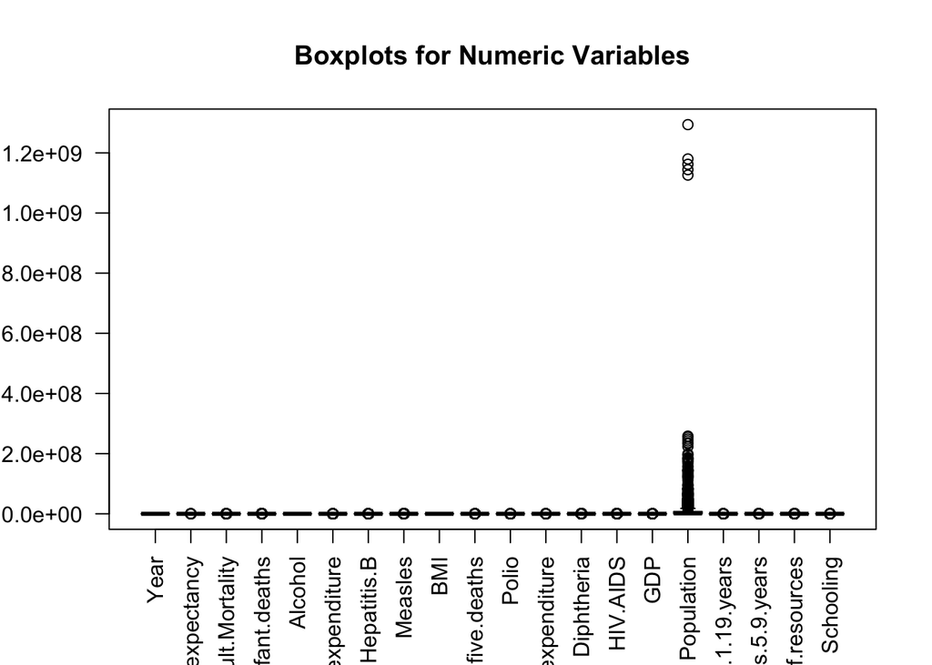

```r
numeric_vars <- sapply(life_expectancy_data, is.numeric)
boxplot(life_expectancy_data[, numeric_vars], main = "Boxplots for Numeric Variables", las = 2)
```

The boxplots are a bit small though. Let’s try to make them bigger.

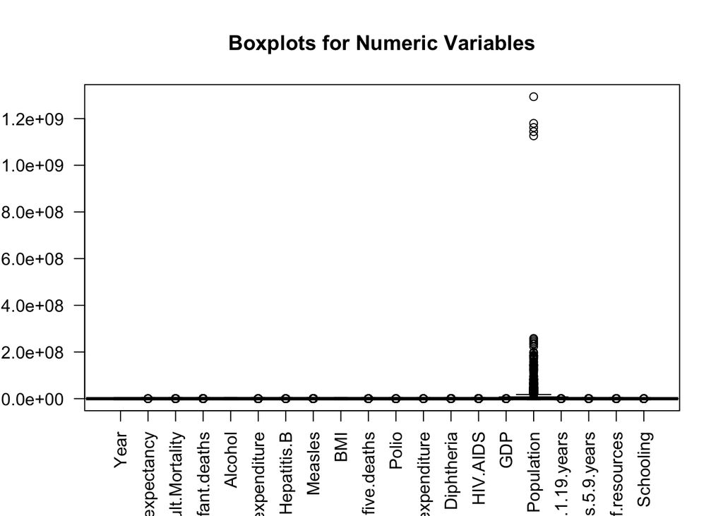

```r
boxplot(life_expectancy_data[, numeric_vars], main = "Boxplots for Numeric Variables", las = 2, boxwex = 2.5)
```

`boxwex` didn’t work. Let’s try another one.

```r
library(reshape2)
long_data <- melt(life_expectancy_data[, numeric_vars])
```

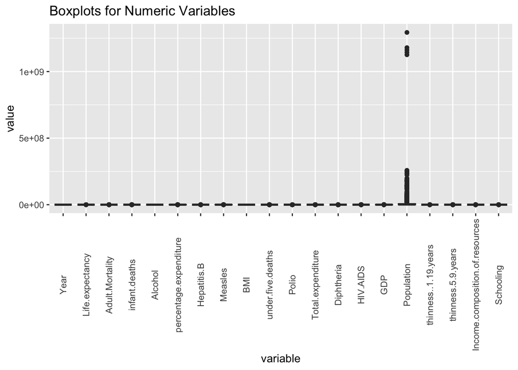

```r
library(ggplot2)
ggplot(long_data, aes(x = variable, y = value)) +
  geom_boxplot() +
  theme(axis.text.x = element_text(angle = 90, vjust = 0.5)) +
  ggtitle("Boxplots for Numeric Variables")
```

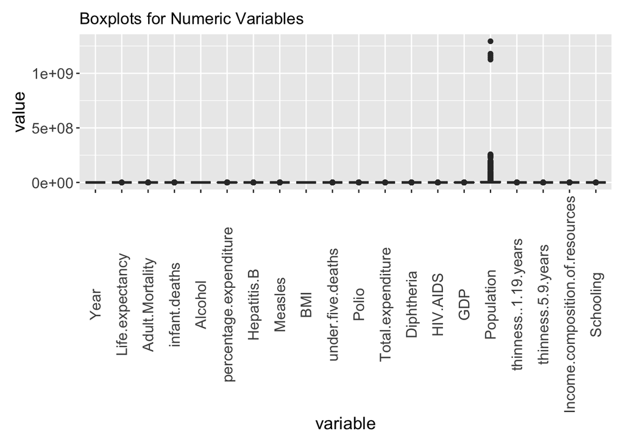

```r
# Create a ggplot boxplot with more control over size
ggplot(long_data, aes(x = variable, y = value)) +
  geom_boxplot() +
  theme(axis.text.x = element_text(angle = 90, vjust = 0.5),  # Rotate labels
        plot.margin = margin(10, 10, 10, 10),  # Adjust plot margins
        axis.text = element_text(size = 12),  # Change axis text size
        axis.title = element_text(size = 14)) +  # Change title size
  ggtitle("Boxplots for Numeric Variables")
```

### Handle missing values and outliers.

Which columns are continuous so that we can fill na with the media (since we have established that we have outliers).

```r
continuous_cols <- colnames(life_expectancy_data)[sapply(life_expectancy_data, is.numeric)]
continuous_cols
```

```
##  [1] "Year"                            "Life.expectancy"
##  [3] "Adult.Mortality"                 "infant.deaths"
##  [5] "Alcohol"                         "percentage.expenditure"
##  [7] "Hepatitis.B"                     "Measles"
##  [9] "BMI"                             "under.five.deaths"
## [11] "Polio"                           "Total.expenditure"
## [13] "Diphtheria"                      "HIV.AIDS"
## [15] "GDP"                             "Population"
## [17] "thinness..1.19.years"            "thinness.5.9.years"
## [19] "Income.composition.of.resources" "Schooling"
```

Now, we replace the NA values in each of the these columns by the median. Now, let’s handle some missing values.

```r
for (col in continuous_cols) {
  life_expectancy_data[[col]] <- ifelse(
    is.na(life_expectancy_data[[col]]),
    median(life_expectancy_data[[col]], na.rm = TRUE), life_expectancy_data[[col]])
}
```

Now, let’s see if we have any missing values.

```r
library(dplyr)
data.frame(Columns = names(colSums(is.na(life_expectancy_data))), class = unname(colSums(is.na(life_expectancy_data)))) %>%
  arrange(desc(class))
```

```
##                            Columns class
## 1                          Country     0
## 2                             Year     0
## 3                           Status     0
## 4                  Life.expectancy     0
## 5                  Adult.Mortality     0
## 6                    infant.deaths     0
## 7                          Alcohol     0
## 8           percentage.expenditure     0
## 9                      Hepatitis.B     0
## 10                         Measles     0
## 11                             BMI     0
## 12               under.five.deaths     0
## 13                           Polio     0
## 14               Total.expenditure     0
## 15                      Diphtheria     0
## 16                        HIV.AIDS     0
## 17                             GDP     0
## 18                      Population     0
## 19            thinness..1.19.years     0
## 20              thinness.5.9.years     0
## 21 Income.composition.of.resources     0
## 22                       Schooling     0
```

Wonderful. Now, let’s handle some outliers. This is fun. 🤩

We are going to use the Interquartile Range (IQR) method to identify and cap or remove outliers.

```r
cap_outliers <- function(x) {
  q1 <- quantile(x, 0.25)
  q3 <- quantile(x, 0.75)
  iqr <- q3 - q1
  lower <- q1 - 1.5 * iqr
  upper <- q3 + 1.5 * iqr
  x[x < lower] <- lower
  x[x > upper] <- upper
  return(x)
}

life_expectancy_data[numeric_vars] <- lapply(life_expectancy_data[numeric_vars], cap_outliers)
```

Let’s see if we still have outliers.

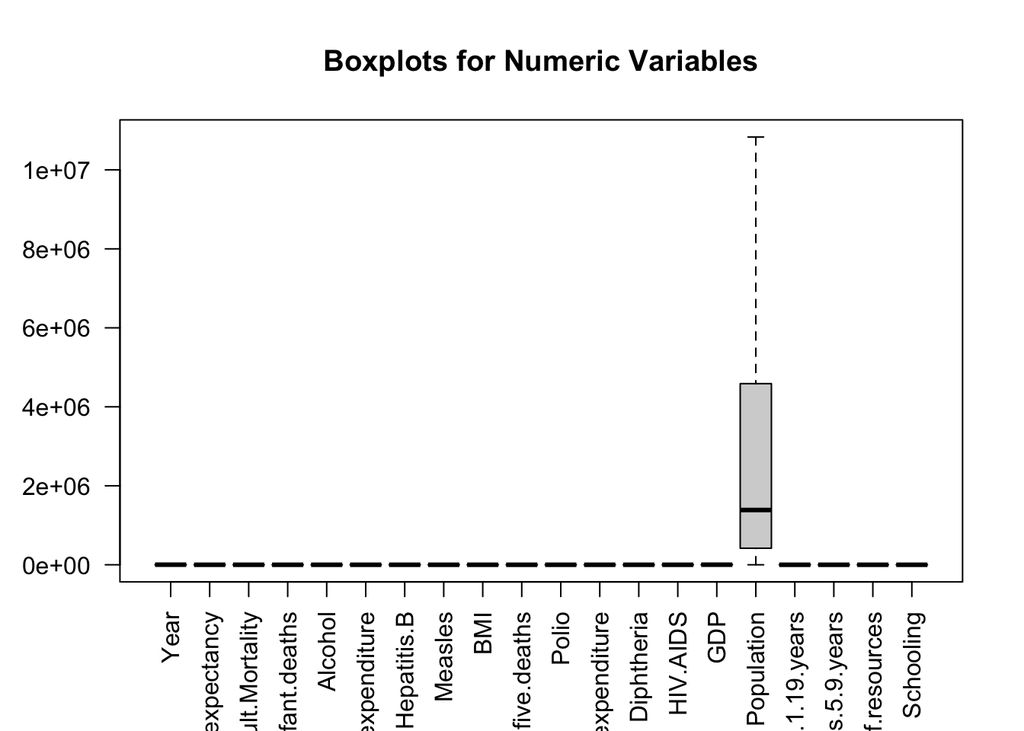

```r
boxplot(life_expectancy_data[, numeric_vars], main = "Boxplots for Numeric Variables", las = 2)
```

Excellent.

## Value Extraction and Plot

```r
head(country_population)
```

```
##   Country.Name Country.Code    Indicator.Name Indicator.Code    X1960    X1961
## 1        Aruba          ABW Population, total    SP.POP.TOTL    54211    55438
## 2  Afghanistan          AFG Population, total    SP.POP.TOTL  8996351  9166764
## 3       Angola          AGO Population, total    SP.POP.TOTL  5643182  5753024
## 4      Albania          ALB Population, total    SP.POP.TOTL  1608800  1659800
## 5      Andorra          AND Population, total    SP.POP.TOTL    13411    14375
## 6   Arab World          ARB Population, total    SP.POP.TOTL 92490932 95044497
##      X1962     X1963     X1964     X1965     X1966     X1967     X1968
## 1    56225     56695     57032     57360     57715     58055     58386
## 2  9345868   9533954   9731361   9938414  10152331  10372630  10604346
## 3  5866061   5980417   6093321   6203299   6309770   6414995   6523791
## 4  1711319   1762621   1814135   1864791   1914573   1965598   2022272
## 5    15370     16412     17469     18549     19647     20758     21890
## 6 97682294 100411076 103239902 106174988 109230593 112406932 115680165
##       X1969     X1970     X1971     X1972     X1973     X1974     X1975
```

[output cut: 48 more lines]

```r
head(population_2016 <- country_population %>% select(`Country.Name`, `X2016`))
```

```
##   Country.Name     X2016
## 1        Aruba    104822
## 2  Afghanistan  34656032
## 3       Angola  28813463
## 4      Albania   2876101
## 5      Andorra     77281
## 6   Arab World 406452690
```

Let’s see if we have any missing values.

```r
colSums(is.na(population_2016))
```

```
## Country.Name        X2016
##            0            2
```

Let’s remove them.

```r
population_2016 <- na.omit(population_2016)
colSums(is.na(population_2016))
```

```
## Country.Name        X2016
##            0            0
```

Get top 10 countries by 2016 population

```r
top10_2016 <- population_2016 %>%
  arrange(desc(`X2016`)) %>%
  slice(1:10)
top10_2016
```

```
##                  Country.Name      X2016
## 1                       World 7444027227
## 2            IDA & IBRD total 6273581970
## 3         Low & middle income 6254072964
## 4               Middle income 5594800288
## 5                   IBRD only 4699229277
## 6  Early-demographic dividend 3170657660
## 7         Lower middle income 3014788232
## 8         Upper middle income 2580012056
## 9         East Asia & Pacific 2298727229
## 10  Late-demographic dividend 2264565982
```

Wait, we getting entries that are not countries. Let’s fix that.

```r
# Define a vector of known non-country entries
non_country_entries <- c("World", "IDA & IBRD total", "Low & middle income", "Middle income",
                         "IBRD only", "Early-demographic dividend", "Lower middle income",
                         "Upper middle income", "East Asia & Pacific", "Late-demographic dividend")

# Filter out non-country entries
countries_only <- population_2016 %>%
  filter(!`Country.Name` %in% non_country_entries)

# Select top 10 countries by population in 2016
top10_2016 <- countries_only %>%
  arrange(desc(`X2016`)) %>%
  slice(1:10)

top10_2016
```

```
##                                   Country.Name      X2016
## 1  East Asia & Pacific (excluding high income) 2053299126
## 2   East Asia & Pacific (IDA & IBRD countries) 2027896410
## 3                                   South Asia 1766393714
## 4                      South Asia (IDA & IBRD) 1766393714
## 5                                    IDA total 1574352693
## 6                                        China 1378665000
## 7                                        India 1324171354
## 8                                 OECD members 1289872625
## 9                                  High income 1189954263
## 10                   Post-demographic dividend 1102651400
```

Still needs more fixing. We’ll use the country code and only select the observations with valid country codes.

```r
population_2016 <- country_population %>% select(`Country.Name`, `Country.Code`, `X2016`)
head(population_2016)
```

```
##   Country.Name Country.Code     X2016
## 1        Aruba          ABW    104822
## 2  Afghanistan          AFG  34656032
## 3       Angola          AGO  28813463
## 4      Albania          ALB   2876101
## 5      Andorra          AND     77281
## 6   Arab World          ARB 406452690
```

```r
valid_iso_codes <- c(
  "AFG", "ALB", "DZA", "AND", "AGO", "ARG", "ARM", "AUS", "AUT", "AZE",
  "BDI", "BEL", "BEN", "BFA", "BGD", "BGR", "BHR", "BIH", "BLR", "BLZ",
  "BOL", "BRA", "BRN", "BTN", "BWA", "CAF", "CAN", "CHE", "CHL", "CHN",
  "CIV", "CMR", "COD", "COG", "COL", "COM", "CPV", "CRI", "CUB", "CYP",
  "CZE", "DEU", "DJI", "DNK", "DOM", "DZA", "ECU", "EGY", "ERI", "ESP",
  "EST", "ETH", "FIN", "FJI", "FRA", "GAB", "GBR", "GEO", "GHA", "GIN",
  "GMB", "GNB", "GNQ", "GRC", "GTM", "GUY", "HND", "HRV", "HTI", "HUN",
  "IDN", "IND", "IRL", "IRN", "IRQ", "ISL", "ISR", "ITA", "JAM", "JOR",
  "JPN", "KAZ", "KEN", "KGZ", "KHM", "KIR", "KOR", "KWT", "LAO", "LBN",
  "LBR", "LBY", "LKA", "LSO", "LTU", "LUX", "LVA", "MAR", "MDA", "MDG",
  "MDV", "MEX", "MKD", "MLI", "MLT", "MMR", "MNE", "MNG", "MOZ", "MRT",
  "MUS", "MWI", "MYS", "NAM", "NER", "NGA", "NIC", "NLD", "NOR", "NPL",
  "NZL", "OMN", "PAK", "PAN", "PER", "PHL", "PNG", "POL", "PRT", "PRY",
  "QAT", "ROU", "RUS", "RWA", "SAU", "SDN", "SEN", "SGP", "SLB", "SLE",
  "SLV", "SOM", "SRB", "SSD", "SUR", "SVK", "SVN", "SWE", "SWZ", "SYR",
  "TCD", "TGO", "THA", "TJK", "TKM", "TLS", "TTO", "TUN", "TUR", "TZA",
  "UGA", "UKR", "URY", "USA", "UZB", "VEN", "VNM", "VUT", "YEM", "ZAF",
  "ZMB", "ZWE"
)

# Filter only valid countries using Country.Code
countries_only <- population_2016 %>%
  filter(Country.Code %in% valid_iso_codes)

# Get top 10 by population in 2016
top10_2016 <- countries_only %>%
  arrange(desc(`X2016`)) %>%
  slice(1:10) %>% select(Country.Name, `X2016`)

top10_2016
```

```
##          Country.Name      X2016
## 1               China 1378665000
## 2               India 1324171354
## 3       United States  323127513
## 4           Indonesia  261115456
## 5              Brazil  207652865
## 6            Pakistan  193203476
## 7             Nigeria  185989640
## 8          Bangladesh  162951560
## 9  Russian Federation  144342396
## 10             Mexico  127540423
```

Beautiful, isn’t it. Let’s move on.

### Visualize with ggplot2

We’ll use a bar chart, which is appropriate for comparing numerical values across categories (countries, in our case).

Plot 2016 population of those top 10 countries

[figure not shown]

```r
ggplot(top10_2016, aes(x = reorder(`Country.Name`, `X2016`), y = `X2016`)) +
  geom_bar(stat = "identity", fill = "steelblue") +
  coord_flip() +  # Flips axes for better readability
  labs(title = "Top 10 Most Populous Countries in 2015 and Their 2016 Population",
       x = "Country",
       y = "Population (2016)") +
  theme_minimal()
```

```r
library(tidyr)
```

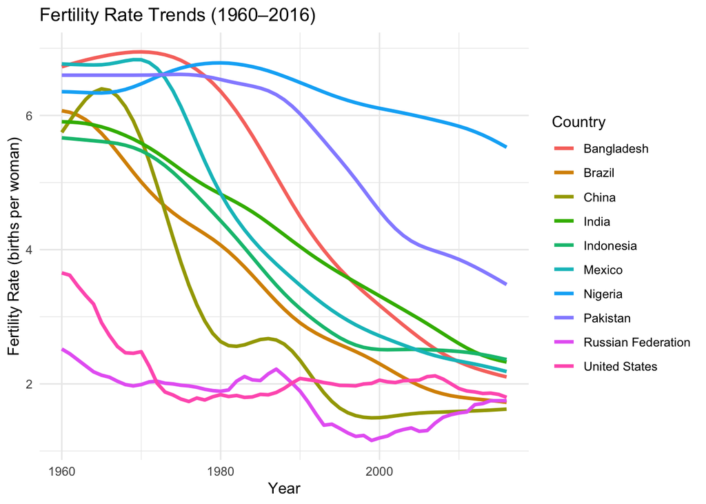

```r
library(readr)
library(stringr)
top_10_countries <- top10_2016$Country.Name

fertility_top <- fertility_rate %>%
  filter(`Country.Name` %in% top_10_countries)

# STEP 3: Reshape to long format
fertility_long <- fertility_top %>%
  pivot_longer(
    cols = `X1960`:`X2016`,
    names_to = "Year",
    values_to = "Fertility_Rate"
  ) %>%
  mutate(
    Year = as.numeric(str_remove(Year, "^X"))
  )

# STEP 4: Plot the trend using ggplot2
ggplot(fertility_long, aes(x = Year, y = Fertility_Rate, color = `Country.Name`)) +
  geom_line(size = 1.2) +
  labs(
    title = "Fertility Rate Trends (1960–2016)",
    x = "Year",
    y = "Fertility Rate (births per woman)",
    color = "Country"
  ) +
  theme_minimal()
```

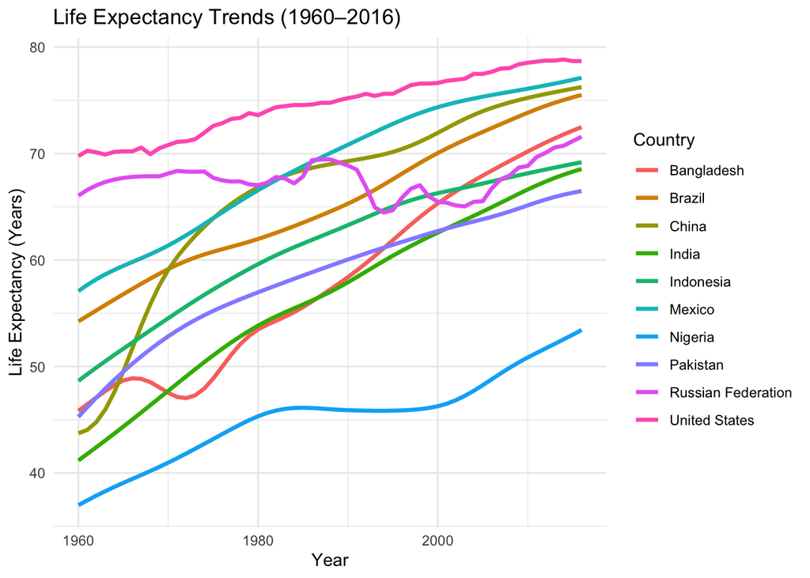

```r
life_expectancy_top <- life_expectancy %>%
  filter(`Country.Name` %in% top_10_countries)

# STEP 3: Reshape to long format (wide ➝ long)
life_expectancy_long <- life_expectancy_top %>%
  pivot_longer(
    cols = `X1960`:`X2016`,
    names_to = "Year",
    values_to = "Life_Expectancy"
  ) %>%
  mutate(
    Year = as.numeric(str_remove(Year, "^X")),
    Life_Expectancy = as.numeric(Life_Expectancy)
  )

# STEP 4: Plot the life expectancy trend
ggplot(life_expectancy_long, aes(x = Year, y = Life_Expectancy, color = `Country.Name`)) +
  geom_line(size = 1.2) +
  labs(
    title = "Life Expectancy Trends (1960–2016)",
    x = "Year",
    y = "Life Expectancy (Years)",
    color = "Country"
  ) +
  theme_minimal()
```

```r
# Selecting only the columns needed for correlation
cols_to_use <- c("Life.expectancy", "Adult.Mortality", "infant.deaths", "Alcohol",
                 "percentage.expenditure", "Hepatitis.B", "Measles", "BMI",
                 "under.five.deaths", "Polio", "Total.expenditure", "Diphtheria",
                 "HIV.AIDS", "GDP", "Population", "thinness..1.19.years",
                 "thinness.5.9.years", "Income.composition.of.resources", "Schooling")

# Subset and remove rows with missing values
data_numeric <- life_expectancy_data[, cols_to_use]
data_numeric <- na.omit(data_numeric)  # Removes rows with any NA values
```

```r
# Calculate correlation matrix using Pearson method (default)
cor_matrix <- cor(data_numeric)

# View the first few rows of correlation matrix
head(cor_matrix)
```

```
##                        Life.expectancy Adult.Mortality infant.deaths    Alcohol
## Life.expectancy              1.0000000      -0.6912369    -0.5670671  0.3900945
## Adult.Mortality             -0.6912369       1.0000000     0.3840186 -0.1992775
## infant.deaths               -0.5670671       0.3840186     1.0000000 -0.3233492
## Alcohol                      0.3900945      -0.1992775    -0.3233492  1.0000000
## percentage.expenditure       0.4877857      -0.3220303    -0.3449310  0.3960792
## Hepatitis.B                  0.2491241      -0.1853933    -0.2926467  0.1387739
##                        percentage.expenditure Hepatitis.B    Measles        BMI
## Life.expectancy                     0.4877857   0.2491241 -0.3371005  0.5578581
## Adult.Mortality                    -0.3220303  -0.1853933  0.2109878 -0.3905756
## infant.deaths                      -0.3449310  -0.2926467  0.5815179 -0.4439698
## Alcohol                             0.3960792   0.1387739 -0.1920181  0.3130310
## percentage.expenditure              1.0000000   0.1286227 -0.1942160  0.3262174
## Hepatitis.B                         0.1286227   1.0000000 -0.2161441  0.1555399
##                        under.five.deaths      Polio Total.expenditure
## Life.expectancy               -0.6040300  0.5629044        0.21464849
## Adult.Mortality                0.4081909 -0.3495496       -0.12646778
## infant.deaths                  0.9942431 -0.4213087       -0.15667480
## Alcohol                       -0.3300651  0.2577087        0.30496213
## percentage.expenditure        -0.3532784  0.2621768        0.18738714
## Hepatitis.B                   -0.2942360  0.5123016        0.07229662
##                        Diphtheria   HIV.AIDS        GDP   Population
## Life.expectancy         0.5686593 -0.7967577  0.5264700 -0.082223850
## Adult.Mortality        -0.3482010  0.6023619 -0.3426757  0.080372354
## infant.deaths          -0.4125584  0.4153314 -0.3632194  0.356666580
## Alcohol                 0.2624255 -0.1902154  0.4004416  0.001614805
## percentage.expenditure  0.2607937 -0.2943756  0.8525453 -0.012929195
## Hepatitis.B             0.5388192 -0.1978305  0.1726774 -0.129571604
##                        thinness..1.19.years thinness.5.9.years
## Life.expectancy                  -0.5086552         -0.5059164
## Adult.Mortality                   0.3393684          0.3468434
## infant.deaths                     0.4235978          0.4397099
## Alcohol                          -0.4319536         -0.4223572
## percentage.expenditure           -0.3285513         -0.3304938
## Hepatitis.B                      -0.1158645         -0.1227328
##                        Income.composition.of.resources  Schooling
## Life.expectancy                              0.7253729  0.7372096
## Adult.Mortality                             -0.4720233 -0.4621869
## infant.deaths                               -0.4069584 -0.5036783
## Alcohol                                      0.4405738  0.5183288
## percentage.expenditure                       0.5037163  0.5252241
## Hepatitis.B                                  0.2047513  0.2283345
```

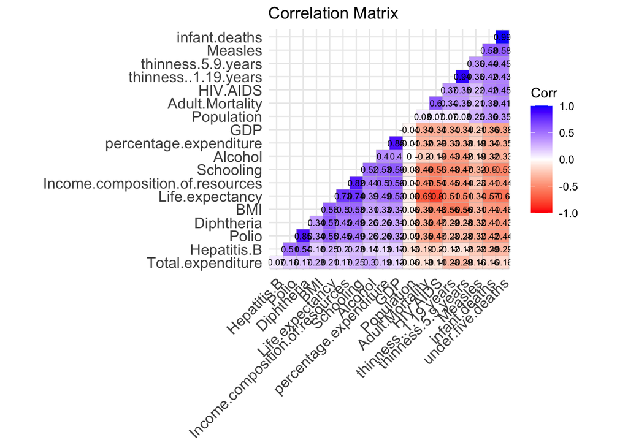

```r
library(ggcorrplot)

ggcorrplot(cor_matrix,
           lab = TRUE,
           lab_size = 2.5,
           method = "square",
           colors = c("red", "white", "blue"),
           title = "Correlation Matrix",
           hc.order = TRUE,
           type = "lower")
```

```r
cor(data_numeric$Life.expectancy, data_numeric$Schooling)
```

```
## [1] 0.7372096
```

This indicates a strong positive correlation between life expectancy and schooling.

Interpretation: A value of 0.73 means that as schooling increases, life expectancy tends to increase as well.

Educated individuals are likely more aware of health risks, make better lifestyle choices, and have access to better jobs and healthcare.

This relationship makes logical sense and suggests that improving education might indirectly improve public health and longevity.

```r
# Check column names of both datasets
names(life_expectancy_data)            # Life expectancy dataset
```

```
##  [1] "Country"                         "Year"
##  [3] "Status"                          "Life.expectancy"
##  [5] "Adult.Mortality"                 "infant.deaths"
##  [7] "Alcohol"                         "percentage.expenditure"
##  [9] "Hepatitis.B"                     "Measles"
## [11] "BMI"                             "under.five.deaths"
## [13] "Polio"                           "Total.expenditure"
## [15] "Diphtheria"                      "HIV.AIDS"
## [17] "GDP"                             "Population"
## [19] "thinness..1.19.years"            "thinness.5.9.years"
## [21] "Income.composition.of.resources" "Schooling"
```

```r
names(fertility_rate)  # Fertility dataset
```

```
##  [1] "Country.Name"   "Country.Code"   "Indicator.Name" "Indicator.Code"
##  [5] "X1960"          "X1961"          "X1962"          "X1963"
##  [9] "X1964"          "X1965"          "X1966"          "X1967"
## [13] "X1968"          "X1969"          "X1970"          "X1971"
## [17] "X1972"          "X1973"          "X1974"          "X1975"
## [21] "X1976"          "X1977"          "X1978"          "X1979"
## [25] "X1980"          "X1981"          "X1982"          "X1983"
## [29] "X1984"          "X1985"          "X1986"          "X1987"
## [33] "X1988"          "X1989"          "X1990"          "X1991"
## [37] "X1992"          "X1993"          "X1994"          "X1995"
## [41] "X1996"          "X1997"          "X1998"          "X1999"
## [45] "X2000"          "X2001"          "X2002"          "X2003"
## [49] "X2004"          "X2005"          "X2006"          "X2007"
## [53] "X2008"          "X2009"          "X2010"          "X2011"
## [57] "X2012"          "X2013"          "X2014"          "X2015"
## [61] "X2016"
```

```r
# Rename columns if needed for consistency (assume they are "Country", "Year", "FertilityRate")
colnames(fertility_rate)[colnames(fertility_rate) == "FertilityRate"] <- "fertility_rate"
```

```r
fertility_long <- fertility_rate %>%
  pivot_longer(
    cols = starts_with("X"),  # All year columns like X1960, X1961...
    names_to = "Year",
    values_to = "fertility_rate"
  )


fertility_long
```

```
## # A tibble: 15,048 × 6
##    Country.Name Country.Code Indicator.Name  Indicator.Code Year  fertility_rate
##    <chr>        <chr>        <chr>           <chr>          <chr>          <dbl>
##  1 Aruba        ABW          Fertility rate… SP.DYN.TFRT.IN X1960           4.82
##  2 Aruba        ABW          Fertility rate… SP.DYN.TFRT.IN X1961           4.66
##  3 Aruba        ABW          Fertility rate… SP.DYN.TFRT.IN X1962           4.47
##  4 Aruba        ABW          Fertility rate… SP.DYN.TFRT.IN X1963           4.27
##  5 Aruba        ABW          Fertility rate… SP.DYN.TFRT.IN X1964           4.06
##  6 Aruba        ABW          Fertility rate… SP.DYN.TFRT.IN X1965           3.84
##  7 Aruba        ABW          Fertility rate… SP.DYN.TFRT.IN X1966           3.62
##  8 Aruba        ABW          Fertility rate… SP.DYN.TFRT.IN X1967           3.42
##  9 Aruba        ABW          Fertility rate… SP.DYN.TFRT.IN X1968           3.23
## 10 Aruba        ABW          Fertility rate… SP.DYN.TFRT.IN X1969           3.05
## # ℹ 15,038 more rows
```

```r
# Check structure
```

```r
# Load libraries
library(tidyverse)
library(caret)      # For RMSE
library(Metrics)    # For RMSE (optional)
library(psych)      # For describe()
```

```r
library(ggplot2)

# Fit the linear regression model
model <- lm(Life.expectancy ~ ., data = life_expectancy_data)

# View model summary
summary(model)
```

```
##
## Call:
## lm(formula = Life.expectancy ~ ., data = life_expectancy_data)
##
## Residuals:
##      Min       1Q   Median       3Q      Max
## -12.6994  -0.9295  -0.2846   0.5226  12.4997
##
## Coefficients: (1 not defined because of singularities)
##                                                               Estimate
## (Intercept)                                                 -4.901e+02
## CountryAlbania                                               7.435e+00
## CountryAlgeria                                               8.080e+00
## CountryAngola                                               -8.033e+00
## CountryAntigua and Barbuda                                   7.988e+00
## CountryArgentina                                             8.272e+00
## CountryArmenia                                               5.777e+00
## CountryAustralia                                             1.428e+01
## CountryAustria                                               1.431e+01
## CountryAzerbaijan                                            3.865e+00
## CountryBahamas                                               7.227e+00
## CountryBahrain                                               7.863e+00
## CountryBangladesh                                            9.915e+00
## CountryBarbados                                              7.491e+00
## CountryBelarus                                               3.122e+00
## CountryBelgium                                               1.296e+01
## CountryBelize                                                1.886e+00
## CountryBenin                                                -3.145e+00
## CountryBhutan                                               -6.511e-01
## CountryBolivia (Plurinational State of)                      1.611e+00
## CountryBosnia and Herzegovina                                8.526e+00
## CountryBotswana                                             -9.927e+00
## CountryBrazil                                                1.259e+01
## CountryBrunei Darussalam                                     8.241e+00
## CountryBulgaria                                              5.913e+00
## CountryBurkina Faso                                         -7.731e-01
## CountryBurundi                                              -5.643e+00
## CountryCabo Verde                                            5.283e+00
## CountryCambodia                                              2.306e-01
## CountryCameroon                                             -3.418e+00
```

[output cut: 602 more lines]

```
## Total.expenditure                                           0.372461
## Diphtheria                                                  1.41e-05 ***
## HIV.AIDS                                                    0.047467 *
## GDP                                                         0.000184 ***
## Population                                                  0.865180
## thinness..1.19.years                                        0.856557
## thinness.5.9.years                                          0.084086 .
## Income.composition.of.resources                             0.883243
## Schooling                                                   0.095464 .
## ---
## Signif. codes:  0 '***' 0.001 '**' 0.01 '*' 0.05 '.' 0.1 ' ' 1
##
## Residual standard error: 1.962 on 2726 degrees of freedom
## Multiple R-squared:  0.9603, Adjusted R-squared:  0.9572
## F-statistic: 312.3 on 211 and 2726 DF,  p-value: < 2.2e-16
```

```r
# Install if not installed already
library(Metrics)
# Predict life expectancy using the model
predictions <- predict(model, newdata = life_expectancy_data)
# Actual values
actual <- life_expectancy_data$Life.expectancy

# Calculate RMSE
rmse_value <- rmse(predictions, actual)

# Print RMSE and R-squared
cat("R-squared:", summary(model)$r.squared, "\n")
```

```
## R-squared: 0.9602722
```

```r
cat("RMSE:", rmse_value, "\n")
```

```
## RMSE: 1.889433
```

```r
# Define EAC countries
eac_countries <- c("Burundi", "Kenya", "Rwanda", "South Sudan", "Tanzania", "Uganda")

# Define SADC countries
sadc_countries <- c("Angola", "Botswana", "Comoros", "Congo, Dem. Rep.",
                    "Eswatini", "Lesotho", "Madagascar", "Malawi", "Mauritius",
                    "Mozambique", "Namibia", "Seychelles", "South Africa",
                    "Tanzania", "Zambia", "Zimbabwe")
```

```r
# Extract EAC and SADC subsets
eac_data <- life_expectancy_data %>%
  filter(Country %in% eac_countries & !is.na(Life.expectancy)) %>%
  mutate(Region = "EAC")

sadc_data <- life_expectancy_data %>%
  filter(Country %in% sadc_countries & !is.na(Life.expectancy)) %>%
  mutate(Region = "SADC")
```

```r
# Combine the two datasets
eac_sadc_data <- bind_rows(eac_data, sadc_data)

# Group by region and calculate average life expectancy
region_life_exp <- eac_sadc_data %>%
  group_by(Region) %>%
  summarise(Average_Life_Expectancy = mean(Life.expectancy))

# View results
print(region_life_exp)
```

```
## # A tibble: 2 × 2
##   Region Average_Life_Expectancy
##   <chr>                    <dbl>
## 1 EAC                       56.4
## 2 SADC                      57.6
```

[figure not shown]

```r
# Bar plot for comparison
ggplot(region_life_exp, aes(x = Region, y = Average_Life_Expectancy, fill = Region)) +
  geom_col() +
  labs(title = "Average Life Expectancy in EAC vs SADC (2013)",
       x = "Region",
       y = "Average Life Expectancy (Years)") +
  theme_minimal() +
  theme(legend.position = "none")
```